# Strategy Session Report — strategy_lgbm_solusdt_fw60_2101_2605

- Show All Code
- Hide All Code

Same-window calibration és optimalizáció | SOLUSDT 1m

Published

2026-06-20

## 1 Cél

Ez a notebook a `strategy_lgbm_solusdt_fw60_2101_2605` strategy session eredményeit mutatja be. A strategy session a két végleges modell (long + short) score-jaiból rank-first döntési logikán keresztül kereskedhető strategy artifact-ot épít.

> **⚠️ Same-window evaluation** — A calibration, az optimalizáció és a riportolt metrikák **mind ugyanazon fit_period ablakra** vonatkoznak. A bemutatott számok tehát nem független holdout bizonyítékok, hanem in-sample fit/measure eredmények. OOS validáció külön feladat.

**Kapcsolódó dokumentáció:** - Módszertan: `_doc_/6000_strategy.md` - Artifact spec: `src/strategy/strategy/artifacts.py`

**Asset:** SOLUSDT | **Granularitás:** 1m | **Dátum:** 2026-06-20

```python
from pathlib import Path
import sys
import json
import pandas as pd
import matplotlib.pyplot as plt
import matplotlib.ticker as mtick
import seaborn as sns
from IPython.display import display, Markdown

# repo root is two levels up from artifacts/<session_id>/
_root = Path.cwd().parent.parent
sys.path.insert(0, str(_root))
sys.path.insert(0, str(_root / "src"))

import analyst.plot_utils as pu
from analyst.table_formatting import display_analysis_table, format_analysis_table

pu.apply_theme()

LONG_COLOR  = pu.LONG_COLOR   # green
SHORT_COLOR = pu.SHORT_COLOR  # red
NEUTRAL_COLOR = pu.NEUTRAL_COLOR

session_dir = Path.cwd()
SESSION_ID  = session_dir.name

# --- Load artifact ---
artifact_path = session_dir / "strategy_artifact.json"
if artifact_path.exists():
    with open(artifact_path) as f:
        artifact = json.load(f)
else:
    artifact = None

# --- Load summary ---
summary_path = session_dir / "summary.json"
summary = json.loads(summary_path.read_text()) if summary_path.exists() else None

# --- Load trades ---
trades_path = session_dir / "trades.parquet"
trades_df = pd.read_parquet(trades_path) if trades_path.exists() else None

# --- Load equity curve ---
eq_path = session_dir / "equity_curve.parquet"
eq_df = pd.read_parquet(eq_path) if eq_path.exists() else None

# --- Load strategy table ---
st_path = session_dir / "strategy_table.parquet"
st_df = pd.read_parquet(st_path) if st_path.exists() else None

# --- Data availability report ---
available = {
    "strategy_artifact.json" : artifact is not None,
    "summary.json"           : summary is not None,
    "trades.parquet"         : trades_df is not None,
    "equity_curve.parquet"   : eq_df is not None,
    "strategy_table.parquet" : st_df is not None,
}
avail_df = pd.DataFrame(
    [{"fájl": k, "elérhető": "✅ igen" if v else "❌ hiányzik"} for k, v in available.items()]
)
display_analysis_table(avail_df)
```

| fájl | elérhető |
| --- | --- |
| strategy_artifact.json | ✅ igen |
| summary.json | ✅ igen |
| trades.parquet | ✅ igen |
| equity_curve.parquet | ✅ igen |
| strategy_table.parquet | ✅ igen |

## 2 Executive Összefoglaló

**Forrás.** `strategy_artifact.json` és `summary.json` — a strategy session optimalizáció utáni legfontosabb metrikái és döntési paraméterei.

**Értelmezés.** A metrikák same-window futtatásból származnak — az MFE proxy alapú equity nem valós PnL, hanem a bucket-szintű várható excursion összege. Az OOS validáció külön futást igényel.

```python
if summary is not None and artifact is not None:
    dp = artifact.get("decision_params", {})
    rows = [
        {"metrika": "session_id",          "érték": artifact.get("session_id", SESSION_ID)},
        {"metrika": "evaluation_mode",     "érték": artifact.get("evaluation_mode", "same_window")},
        {"metrika": "fit_period_start",    "érték": artifact.get("fit_period", {}).get("start", "—")},
        {"metrika": "fit_period_end",      "érték": artifact.get("fit_period", {}).get("end", "—")},
        {"metrika": "long_model",          "érték": artifact.get("long_model", "—")},
        {"metrika": "short_model",         "érték": artifact.get("short_model", "—")},
        {"metrika": "signal_mode",         "érték": artifact.get("signal_mode", "rank_first")},
        {"metrika": "n_trades",            "érték": str(summary.get("n_trades", "—"))},
        {"metrika": "win_rate",            "érték": f"{summary['win_rate']:.2%}" if summary.get('win_rate') is not None else "—"},
        {"metrika": "gross_return (MFE)",  "érték": f"{summary.get('gross_return', 0):.4f}"},
        {"metrika": "net_return (MFE)",    "érték": f"{summary.get('net_return', 0):.4f}"},
        {"metrika": "initial_capital",     "érték": str(summary.get("initial_capital", 1.0))},
        {"metrika": "final_equity (MFE)",  "érték": f"{summary.get('final_equity', 1.0):.6f}"},
        {"metrika": "equity_basis",        "érték": summary.get("equity_basis", "mfe_proxy")},
        {"metrika": "long_entry_pct",      "érték": str(dp.get("long_entry_pct", "—"))},
        {"metrika": "short_entry_pct",     "érték": str(dp.get("short_entry_pct", "—"))},
        {"metrika": "min_edge_gap",        "érték": str(dp.get("min_edge_gap", "—"))},
        {"metrika": "max_hold_minutes",    "érték": str(dp.get("max_hold_minutes", "—"))},
        {"metrika": "cooldown_minutes",    "érték": str(dp.get("cooldown_minutes", "—"))},
    ]
    exec_df = pd.DataFrame(rows)
    display_analysis_table(exec_df)
    display(Markdown(
        f"> **⚠️ Same-window:** `evaluation_mode = {artifact.get('evaluation_mode', 'same_window')}` — "
        "a riportált metrikák nem OOS bizonyítékok."
    ))
elif summary is not None:
    rows = [
        {"metrika": k, "érték": str(v)}
        for k, v in summary.items()
    ]
    display_analysis_table(pd.DataFrame(rows))
else:
    display(Markdown(
        "**strategy_artifact.json és summary.json nem elérhető.** "
        "Futtasd a strategy pipeline-t (01_calibrate + 02_optimize) a session létrehozásához."
    ))
```

Table 1: Executive összefoglaló — session metrikák és döntési paraméterek

| metrika | érték |
| --- | --- |
| session_id | strategy_lgbm_solusdt_fw60_2101_2605 |
| evaluation_mode | same_window |
| fit_period_start | 2025-05-01 |
| fit_period_end | 2026-05-31 |
| long_model | lgbm_solusdt_l_fw60_2101_2605 |
| short_model | lgbm_solusdt_s_fw60_2101_2605 |
| signal_mode | rank_first |
| n_trades | 83 |
| win_rate | 91.57% |
| gross_return (MFE) | 0.4775 |
| net_return (MFE) | 0.4775 |
| initial_capital | 1.0 |
| final_equity (MFE) | 1.477515 |
| equity_basis | mfe_proxy |
| long_entry_pct | 0.8086166344657351 |
| short_entry_pct | 0.9757071488588757 |
| min_edge_gap | 0.21959818254342153 |
| max_hold_minutes | 156 |
| cooldown_minutes | 31 |

> **⚠️ Same-window:** `evaluation_mode = same_window` — a riportált metrikák nem OOS bizonyítékok.

## 3 Strategy Summary

**Mi ez.** A strategy session aggregált teljesítmény-összefoglalója.

**Forrás.** `summary.json` — az `optimize_strategy()` által a legjobb Optuna paraméterekre visszaszimulált trade ledger alapján számolt metrikák.

**Értelmezés.** Ha `n_trades` alacsony (< 30), a `win_rate` megbízhatatlan. Ha `gross_return` pozitív, de `n_trades` magas küszöb (≥ 0.90 pct) mellett jön, az erős szelekcióra utal. Same-window biassal kell számolni.

```python
if summary is not None:
    key_order = ["initial_capital", "final_equity", "n_trades", "win_rate",
                 "gross_return", "net_return", "equity_basis", "note"]
    rows = [{"metrika": k, "érték": str(summary.get(k, "—"))} for k in key_order if k in summary]
    # append any extra fields
    for k, v in summary.items():
        if k not in key_order:
            rows.append({"metrika": k, "érték": str(v)})
    sum_df = pd.DataFrame(rows)
    display_analysis_table(sum_df)
    note_val = summary.get("note", "")
    basis_val = summary.get("equity_basis", "mfe_proxy")
    display(Markdown(
        f"**equity_basis:** `{basis_val}` — {note_val}"
    ))
else:
    display(Markdown(
        "**summary.json nem elérhető** — futtasd a strategy pipeline-t a session létrehozásához."
    ))
```

Table 2: Strategy summary — headline metrikák (MFE proxy alapú)

| metrika | érték |
| --- | --- |
| initial_capital | 1.0 |
| final_equity | 1.477515 |
| n_trades | 83 |
| win_rate | 0.915663 |
| gross_return | 0.477515 |
| net_return | 0.477515 |
| equity_basis | mfe_proxy |
| note | entry_price and exit_price reflect close at entry/exit timestamps; equity still uses bucket_mean_mfe as proxy return per trade |

**equity_basis:** `mfe_proxy` — entry_price and exit_price reflect close at entry/exit timestamps; equity still uses bucket_mean_mfe as proxy return per trade

```python
if trades_df is not None and len(trades_df) > 0:
    display_analysis_table(trades_df.head(20))
    display(Markdown(
        f"**Összes trade:** {len(trades_df)} | "
        f"**Long:** {(trades_df['direction'] == 'long').sum()} | "
        f"**Short:** {(trades_df['direction'] == 'short').sum()}"
    ))
elif trades_df is not None and len(trades_df) == 0:
    display(Markdown(
        "**trades.parquet üres** — a strategy nem generált trade-et a megadott paraméterekkel. "
        "Csökkentsd az entry percentile küszöböt vagy bővítsd az időablakot."
    ))
else:
    display(Markdown(
        "**trades.parquet nem elérhető** — futtasd a strategy pipeline-t (02_optimize_strategy.py)"
        " a trade ledger előállításához."
    ))
```

Table 3: Trade ledger — első 20 trade

| entry_time | exit_time | direction | entry_price | exit_price | hold_minutes | exit_reason | score_pct_at_entry | bucket_mean_mfe |
| --- | --- | --- | --- | --- | --- | --- | --- | --- |
| 2025-05-01 14:01:00 | 2025-05-01 16:37:00 | long | 151.150 | 152.500 | 156 | max_hold | 88.26% | 0.006 |
| 2025-05-06 13:51:00 | 2025-05-06 16:27:00 | long | 141.770 | 142.940 | 156 | max_hold | 83.18% | 0.006 |
| 2025-05-07 18:01:00 | 2025-05-07 20:37:00 | long | 145.990 | 145.840 | 156 | max_hold | 86.85% | 0.006 |
| 2025-05-25 15:22:00 | 2025-05-25 17:01:00 | long | 169.570 | 170.380 | 99 | signal_decay | 81.67% | 0.006 |
| 2025-05-27 21:34:00 | 2025-05-27 22:59:00 | long | 176.830 | 176.570 | 85 | signal_decay | 80.91% | 0.006 |
| 2025-05-28 13:48:00 | 2025-05-28 16:24:00 | long | 172.580 | 170.580 | 156 | max_hold | 84.86% | 0.006 |
| 2025-05-29 13:56:00 | 2025-05-29 16:32:00 | long | 170.520 | 169.080 | 156 | max_hold | 85.33% | 0.006 |
| 2025-06-03 13:36:00 | 2025-06-03 16:12:00 | long | 160.490 | 161.620 | 156 | max_hold | 84.16% | 0.006 |
| 2025-06-09 13:56:00 | 2025-06-09 15:57:00 | long | 153.300 | 155.130 | 121 | signal_decay | 82.60% | 0.006 |
| 2025-06-12 15:29:00 | 2025-06-12 18:05:00 | long | 158.210 | 159.440 | 156 | max_hold | 82.38% | 0.006 |
| 2025-06-14 20:43:00 | 2025-06-14 22:30:00 | long | 142.880 | 144.240 | 107 | signal_decay | 81.52% | 0.006 |
| 2025-06-16 13:38:00 | 2025-06-16 16:14:00 | long | 155.180 | 157.500 | 156 | max_hold | 80.88% | 0.006 |
| 2025-06-19 17:37:00 | 2025-06-19 18:48:00 | long | 145.090 | 145.110 | 71 | signal_decay | 81.11% | 0.006 |
| 2025-06-25 13:39:00 | 2025-06-25 16:15:00 | long | 146.680 | 144.010 | 156 | max_hold | 87.39% | 0.006 |
| 2025-06-26 13:37:00 | 2025-06-26 16:13:00 | long | 142.370 | 142.330 | 156 | max_hold | 81.26% | 0.006 |
| 2025-06-29 22:20:00 | 2025-06-30 00:56:00 | long | 153.830 | 152.610 | 156 | max_hold | 91.09% | 0.009 |
| 2025-07-02 13:36:00 | 2025-07-02 16:12:00 | long | 148.470 | 152.350 | 156 | max_hold | 83.20% | 0.006 |
| 2025-07-06 20:25:00 | 2025-07-06 21:31:00 | short | 151.560 | 153.620 | 66 | opposite_edge | 97.74% | -0.002 |
| 2025-07-07 13:49:00 | 2025-07-07 16:25:00 | long | 151.790 | 149.990 | 156 | max_hold | 81.63% | 0.006 |
| 2025-07-09 14:26:00 | 2025-07-09 15:52:00 | long | 155.090 | 153.870 | 86 | signal_decay | 85.63% | 0.006 |

**Összes trade:** 83 | **Long:** 76 | **Short:** 7

## 5 Score Percentile eloszlás entry időpontban

**Mi ez.** Az entry trade-ek score percentile értékeinek eloszlása irányonként.

**Forrás.** `trades.parquet` — `score_pct_at_entry` oszlop, `direction` szerinti bontásban.

**Módszer.** Histogram 20 binnel, long és short irány külön színnel (zöld / piros). A magas percentile tartományba koncentrált eloszlás az entry szelekció hatékonyságát jelzi.

**Értelmezés.** Ha a legtöbb trade ≥ 0.90 percentile-en nyílt, az entry szűrő jól működik. Szórt eloszlás szélsőértékek közelében mechanizmus-gyengeséget jelezhet.

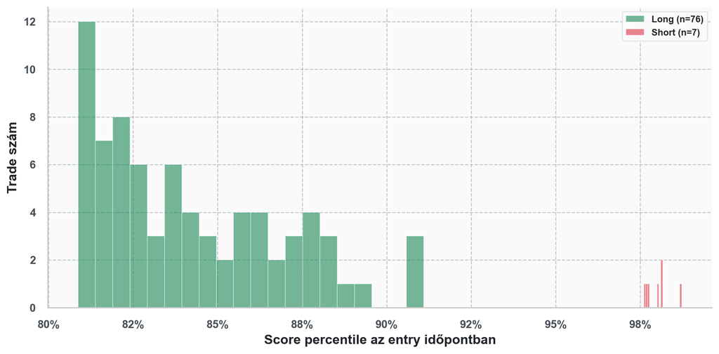

Figure 1: Score percentile eloszlás entry időpontban irányonként

```python
if trades_df is not None and len(trades_df) > 0 and "score_pct_at_entry" in trades_df.columns:
    fig, ax = plt.subplots(figsize=(10, 5))
    for direction, color, label in [
        ("long",  LONG_COLOR,  "Long"),
        ("short", SHORT_COLOR, "Short"),
    ]:
        sub = trades_df[trades_df["direction"] == direction]["score_pct_at_entry"].dropna()
        if len(sub) > 0:
            ax.hist(sub, bins=20, color=color, alpha=0.6, label=f"{label} (n={len(sub)})",
                    edgecolor="white", linewidth=0.5)
    ax.set_xlabel("Score percentile az entry időpontban")
    ax.set_ylabel("Trade szám")
    ax.legend()
    ax.xaxis.set_major_formatter(mtick.PercentFormatter(xmax=1.0, decimals=0))
    ax.spines["top"].set_visible(False)
    ax.spines["right"].set_visible(False)
    plt.tight_layout()
    plt.show()
else:
    display(Markdown(
        "**Nem elérhető** — `trades.parquet` hiányzik vagy üres."
    ))
```

## 6 Equity Curve (MFE Proxy)

**Mi ez.** Kumulatív MFE proxy equity görbe trade sorrendben.

**Forrás.** `equity_curve.parquet` — `trade_index` és `cumulative_mfe` oszlopok.

**Értelmezés.** Monoton emelkedő görbe erős szelekcióra és pozitív edge-re utal. Lapos vagy csökkenő görbe azt jelzi, hogy az entry küszöb nem különíti el a jó excursion trade-eket. Same-window bias: a calibration ugyanerre az ablakra készült, ezért az eredmény optimisztikus.

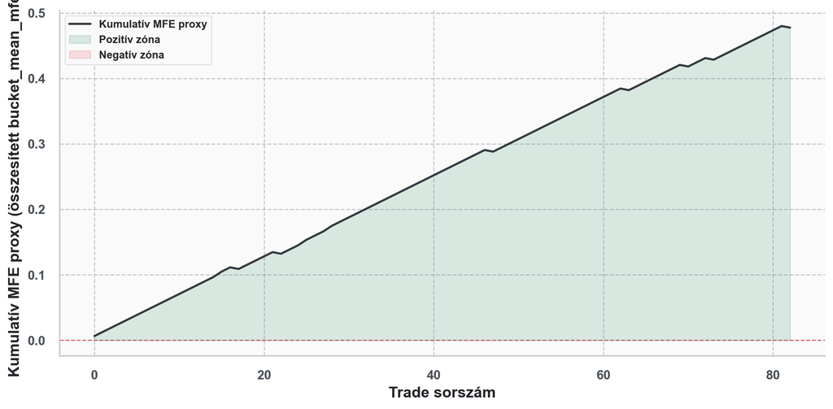

(a) Kumulatív MFE proxy equity görbe (same-window, nem valós PnL)

**Végső kumulatív MFE proxy:** 0.4775 (pozitív zárás). MFE proxy — nem valós PnL.

(b)

Figure 2

```python
if eq_df is not None and len(eq_df) > 0:
    fig, ax = plt.subplots(figsize=(10, 5))
    ax.plot(eq_df["trade_index"], eq_df["cumulative_mfe"],
            color=pu.ACCENT, lw=1.8, label="Kumulatív MFE proxy")
    ax.axhline(0, color=SHORT_COLOR, lw=0.9, linestyle="--", alpha=0.7)
    ax.fill_between(
        eq_df["trade_index"],
        eq_df["cumulative_mfe"],
        0,
        where=eq_df["cumulative_mfe"] >= 0,
        alpha=0.15,
        color=LONG_COLOR,
        label="Pozitív zóna",
    )
    ax.fill_between(
        eq_df["trade_index"],
        eq_df["cumulative_mfe"],
        0,
        where=eq_df["cumulative_mfe"] < 0,
        alpha=0.15,
        color=SHORT_COLOR,
        label="Negatív zóna",
    )
    ax.set_xlabel("Trade sorszám")
    ax.set_ylabel("Kumulatív MFE proxy (összesített bucket_mean_mfe)")
    ax.legend()
    ax.spines["top"].set_visible(False)
    ax.spines["right"].set_visible(False)
    plt.tight_layout()
    plt.show()
    final_eq = eq_df["cumulative_mfe"].iloc[-1]
    direction_text = "pozitív" if final_eq > 0 else "negatív"
    display(Markdown(
        f"**Végső kumulatív MFE proxy:** {final_eq:.4f} ({direction_text} zárás). "
        "MFE proxy — nem valós PnL."
    ))
else:
    display(Markdown(
        "**equity_curve.parquet nem elérhető vagy üres** — futtasd a strategy pipeline-t."
    ))
```

## 7 Havi árfolyam és Trade markerek

**Mi ez.** Live-szerű strategy vizualizáció havi bontásban: a `close` árfolyam felett jelölve a long és short belépők, valamint a kiszállók. A cél az, hogy a strategy session úgy legyen olvasható, mintha az éles felületen néznénk vissza a döntéseket.

**Forrás.** `strategy_table.parquet` (`open_time`, `close`) és `trades.parquet` (`entry_time`, `exit_time`, `entry_price`, `exit_price`, `direction`).

**Módszer.** Minden hónap külön panelen jelenik meg. Az árfolyamot vonalként rajzoljuk. A long entry zöld, felfelé mutató háromszögként az ábra alsó jelölősávjába kerül, a short entry piros, lefelé mutató háromszögként a felső jelölősávba kerül. Az exit pontokat szürke kör és függőleges szaggatott vonal jelöli, így a belépés és a zárás időpontja egyből látható.

**Értelmezés.** Ez a nézet ténylegesen azt mutatja meg, hogy a program hol szállt volna be, mennyi ideig tartotta volna a pozíciót, és hol szállt volna ki az adott hónapban.

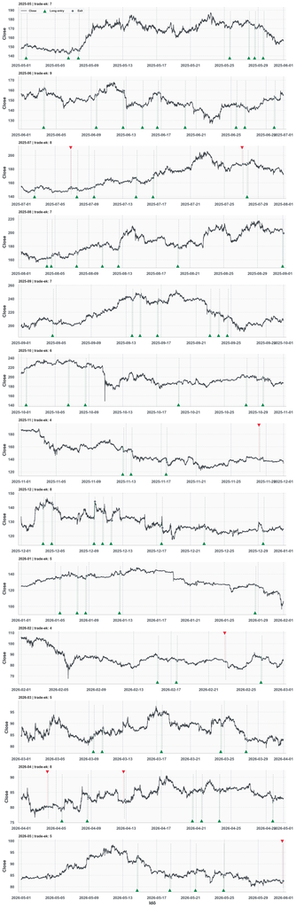

Figure 3: Havi close árfolyam trade markerekkel (long=zöld ▲, short=piros ▼, exit=szürke ○)

```python
if st_df is not None and trades_df is not None and not st_df.empty and not trades_df.empty and "close" in st_df.columns:
    price_df = st_df.copy()
    price_df["open_time"] = pd.to_datetime(price_df["open_time"], errors="coerce")
    price_df["close"] = pd.to_numeric(price_df["close"], errors="coerce")
    price_df = (
        price_df.dropna(subset=["open_time", "close"])
        .sort_values("open_time")
        .drop_duplicates(subset=["open_time"])
        .reset_index(drop=True)
    )

    chart_trades = trades_df.copy()
    chart_trades["entry_time"] = pd.to_datetime(chart_trades["entry_time"], errors="coerce")
    chart_trades["exit_time"] = pd.to_datetime(chart_trades["exit_time"], errors="coerce")
    chart_trades["entry_price"] = pd.to_numeric(chart_trades["entry_price"], errors="coerce")
    chart_trades["exit_price"] = pd.to_numeric(chart_trades["exit_price"], errors="coerce")
    chart_trades = chart_trades.dropna(subset=["entry_time", "exit_time", "entry_price", "exit_price"]).copy()

    month_keys = sorted(price_df["open_time"].dt.to_period("M").unique())
    n_months = len(month_keys)
    fig, axes = plt.subplots(n_months, 1, figsize=(12, max(2.8 * n_months, 6)), sharex=False)
    if n_months == 1:
        axes = [axes]

    for ax, period in zip(axes, month_keys):
        month_mask = price_df["open_time"].dt.to_period("M") == period
        month_df = price_df.loc[month_mask].copy()
        month_start = month_df["open_time"].min()
        month_end = month_df["open_time"].max()

        month_trades = chart_trades[
            (chart_trades["entry_time"] >= month_start) &
            (chart_trades["entry_time"] <= month_end)
        ].copy()

        ax.plot(month_df["open_time"], month_df["close"], color=pu.ACCENT, lw=1.2, alpha=0.95, label="Close")

        y_min = float(month_df["close"].min())
        y_max = float(month_df["close"].max())
        y_span = max(y_max - y_min, 1e-9)
        lane_pad = y_span * 0.08
        long_lane_y = y_min - lane_pad
        short_lane_y = y_max + lane_pad
        exit_low = y_min - lane_pad * 0.35
        exit_high = y_max + lane_pad * 0.35

        long_trades = month_trades[month_trades["direction"] == "long"]
        short_trades = month_trades[month_trades["direction"] == "short"]

        if not long_trades.empty:
            ax.scatter(
                long_trades["entry_time"],
                [long_lane_y] * len(long_trades),
                marker="^",
                s=120,
                color=LONG_COLOR,
                edgecolor="white",
                linewidth=0.8,
                zorder=6,
                label="Long entry",
            )
            ax.vlines(
                long_trades["entry_time"],
                ymin=long_lane_y + lane_pad * 0.1,
                ymax=long_trades["entry_price"],
                colors=LONG_COLOR,
                linestyles="dotted",
                linewidth=1.0,
                alpha=0.65,
                zorder=4,
            )

        if not short_trades.empty:
            ax.scatter(
                short_trades["entry_time"],
                [short_lane_y] * len(short_trades),
                marker="v",
                s=120,
                color=SHORT_COLOR,
                edgecolor="white",
                linewidth=0.8,
                zorder=6,
                label="Short entry",
            )
            ax.vlines(
                short_trades["entry_time"],
                ymin=short_trades["entry_price"],
                ymax=short_lane_y - lane_pad * 0.1,
                colors=SHORT_COLOR,
                linestyles="dotted",
                linewidth=1.0,
                alpha=0.65,
                zorder=4,
            )

        if not month_trades.empty:
            ax.scatter(
                month_trades["exit_time"],
                month_trades["exit_price"],
                marker="o",
                s=46,
                color=NEUTRAL_COLOR,
                edgecolor="white",
                linewidth=0.8,
                zorder=7,
                label="Exit",
            )
            ax.vlines(
                month_trades["exit_time"],
                ymin=exit_low,
                ymax=exit_high,
                colors=NEUTRAL_COLOR,
                linestyles="--",
                linewidth=0.9,
                alpha=0.45,
                zorder=3,
            )

        for trade in month_trades.itertuples(index=False):
            seg_color = LONG_COLOR if trade.direction == "long" else SHORT_COLOR
            ax.plot(
                [trade.entry_time, trade.exit_time],
                [trade.entry_price, trade.exit_price],
                color=seg_color,
                lw=1.1,
                alpha=0.55,
                zorder=5,
            )

        ax.set_ylim(y_min - lane_pad * 1.6, y_max + lane_pad * 1.6)
        trade_count = len(month_trades)
        ax.set_title(f"{period.strftime('%Y-%m')} | trade-ek: {trade_count}", loc="left", fontsize=10, pad=6)
        ax.set_ylabel("Close")
        ax.grid(True, axis="y", alpha=0.22, linestyle="--")
        ax.margins(x=0.01)

    axes[-1].set_xlabel("Idő")
    handles, labels = axes[0].get_legend_handles_labels()
    if handles:
        uniq = dict(zip(labels, handles))
        axes[0].legend(uniq.values(), uniq.keys(), loc="upper left", ncol=4, fontsize=8, frameon=True)
    plt.tight_layout()
else:
    display(Markdown(
        "**Nem jeleníthető meg a live-szerű havi strategy chart** – a `strategy_table.parquet` nem tartalmaz `close` oszlopot, "
        "vagy a `trades.parquet` hiányzik / üres. Futtasd újra a strategy pipeline-t az árfolyam alapú artifacthoz."
    ))
```

## 8 Hold idő eloszlás és exit okok

**Mi ez.** Két kiegészítő nézet a trade-ek viselkedéséről: az exit oka szerinti megoszlás és a tartási idő eloszlása.

**Forrás.** `trades.parquet` — `exit_reason` és `hold_minutes` oszlopok.

**Módszer.** Bal panel: `exit_reason` értékek bar chartja (max_hold / signal_decay / opposite_edge). Jobb panel: `hold_minutes` histogram 20 binnel.

**Értelmezés.** Ha a trade-ek többsége `max_hold`-dal zár, a tartási idő korlátja aktív. Ha `signal_decay` dominál, a strategy proaktívan zár, mielőtt a hold limit eléri. `opposite_edge` domináns arány erős irányváltás szignálokra utal az adott időablakban.

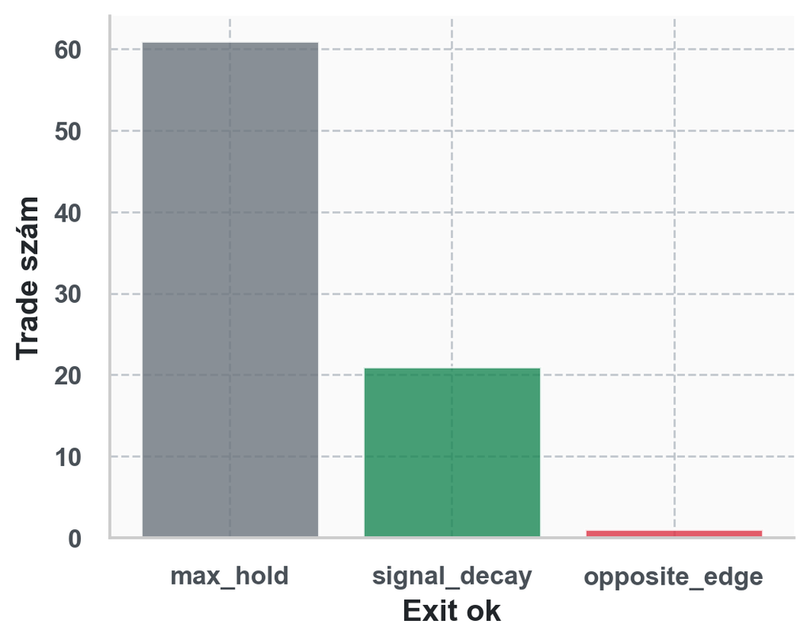

(a) Exit okok megoszlása

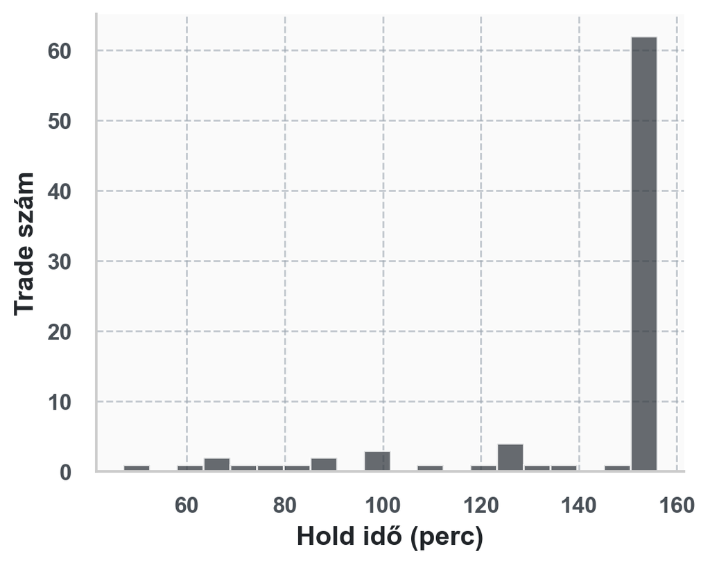

(b) Hold idő (perc) eloszlása

Figure 4: Hold idő eloszlás és exit okok

```python
if trades_df is not None and len(trades_df) > 0:
    # --- Panel 1: exit reason bar chart ---
    if "exit_reason" in trades_df.columns:
        exit_counts = trades_df["exit_reason"].value_counts().reset_index()
        exit_counts.columns = ["exit_reason", "count"]
        fig1, ax1 = plt.subplots(figsize=(5, 4))
        colors_exit = {
            "max_hold":      pu.NEUTRAL_COLOR,
            "signal_decay":  LONG_COLOR,
            "opposite_edge": SHORT_COLOR,
        }
        bar_colors = [colors_exit.get(r, pu.NEUTRAL_COLOR) for r in exit_counts["exit_reason"]]
        ax1.bar(exit_counts["exit_reason"], exit_counts["count"], color=bar_colors, alpha=0.8, edgecolor="white")
        ax1.set_xlabel("Exit ok")
        ax1.set_ylabel("Trade szám")
        ax1.spines["top"].set_visible(False)
        ax1.spines["right"].set_visible(False)
        plt.tight_layout()
        plt.show()
    else:
        display(Markdown("exit_reason oszlop nem elérhető."))

    # --- Panel 2: hold minutes histogram ---
    if "hold_minutes" in trades_df.columns:
        fig2, ax2 = plt.subplots(figsize=(5, 4))
        ax2.hist(trades_df["hold_minutes"].dropna(), bins=20, color=pu.ACCENT, alpha=0.75, edgecolor="white")
        ax2.set_xlabel("Hold idő (perc)")
        ax2.set_ylabel("Trade szám")
        ax2.spines["top"].set_visible(False)
        ax2.spines["right"].set_visible(False)
        plt.tight_layout()
        plt.show()
    else:
        display(Markdown("hold_minutes oszlop nem elérhető."))
else:
    display(Markdown(
        "**trades.parquet nem elérhető vagy üres** — futtasd a strategy pipeline-t."
    ))
    # Placeholder empty figure pair to keep layout
    fig1, ax1 = plt.subplots(figsize=(5, 4))
    ax1.text(0.5, 0.5, "Nincs adat", ha="center", va="center", transform=ax1.transAxes)
    ax1.set_axis_off()
    plt.show()
    fig2, ax2 = plt.subplots(figsize=(5, 4))
    ax2.text(0.5, 0.5, "Nincs adat", ha="center", va="center", transform=ax2.transAxes)
    ax2.set_axis_off()
    plt.show()
```

## 9 Döntési szempontok

**Mi ez.** Döntést támogató értelmezés a futtatott metrikák és ábrák alapján. Az alábbi következtetések a strategy session eredményére vonatkoznak.

**Módszer.** Programmatikusan generált olvasat a `summary.json` és `trades.parquet` alapján.

**Fontos korlát.** Minden metrika same-window — a calibration és az optimalizáció ugyanazon ablakra készült, ahol mérünk. Az OOS validáció külön futás.

```python
rows = []

if summary is not None:
    n_trades  = summary.get("n_trades", 0)
    win_rate  = summary.get("win_rate", None)
    gross_ret = summary.get("gross_return", 0.0)

    # --- n_trades assessment ---
    if n_trades == 0:
        rows.append({
            "szempont": "Trade szám elegend?-e?",
            "érték": f"{n_trades}",
            "értékelés": "KRITIKUS — nincs trade. Csökkentsd a percentile küszöböt.",
        })
    elif n_trades < 20:
        rows.append({
            "szempont": "Trade szám elegend?-e?",
            "érték": f"{n_trades}",
            "értékelés": "GYENGE — kevés trade, win_rate megbízhatatlan. Min. 30+ ajánlott.",
        })
    elif n_trades < 50:
        rows.append({
            "szempont": "Trade szám elegend?-e?",
            "érték": f"{n_trades}",
            "értékelés": "MÉRSÉKELT — elfogadható, de OOS-on is ellenőrizd.",
        })
    else:
        rows.append({
            "szempont": "Trade szám elegend?-e?",
            "érték": f"{n_trades}",
            "értékelés": "OK — kellő minta a win_rate becsléshez.",
        })

    # --- win_rate assessment ---
    if win_rate is None:
        rows.append({
            "szempont": "Win rate jelez edge-et?",
            "érték": "—",
            "értékelés": "Nem számolható (nincs trade).",
        })
    elif win_rate >= 0.60:
        rows.append({
            "szempont": "Win rate jelez edge-et?",
            "érték": f"{win_rate:.2%}",
            "értékelés": "ERŐS — 60%+ win rate pozitív edge-re utal. Same-window biassal számolj.",
        })
    elif win_rate >= 0.50:
        rows.append({
            "szempont": "Win rate jelez edge-et?",
            "érték": f"{win_rate:.2%}",
            "értékelés": "MÉRSÉKELT — 50-60% tartomány, OOS-on ellenőrizendő.",
        })
    else:
        rows.append({
            "szempont": "Win rate jelez edge-et?",
            "érték": f"{win_rate:.2%}",
            "értékelés": "GYENGE — 50% alatti win rate. Felülvizsgálandó.",
        })

    # --- gross_return assessment ---
    if gross_ret > 0:
        rows.append({
            "szempont": "MFE proxy gross_return pozitív-e?",
            "érték": f"{gross_ret:.4f}",
            "értékelés": "POZITÍV — MFE proxy szinten a strategy nyereséges volt az ablakban.",
        })
    else:
        rows.append({
            "szempont": "MFE proxy gross_return pozitív-e?",
            "érték": f"{gross_ret:.4f}",
            "értékelés": "NEGATÍV — MFE proxy szinten veszteséges. Felülvizsgálandó.",
        })

    # --- same-window bias reminder ---
    rows.append({
        "szempont": "Same-window bias",
        "érték": "evaluation_mode=same_window",
        "értékelés": "Minden fenti szám in-sample fit eredmény. OOS validáció kötelező a döntés előtt.",
    })
else:
    rows.append({
        "szempont": "summary.json elérhető-e?",
        "érték": "❌ hiányzik",
        "értékelés": "Futtasd a strategy pipeline-t (01_calibrate + 02_optimize) a session létrehozásához.",
    })

decision_df = pd.DataFrame(rows)
display_analysis_table(decision_df)
```

Table 4: Döntési elemzés — strategy session értékelési szempontok

| szempont | érték | értékelés |
| --- | --- | --- |
| Trade szám elegend?-e? | 83 | OK — kellő minta a win_rate becsléshez. |
| Win rate jelez edge-et? | 91.57% | ERŐS — 60%+ win rate pozitív edge-re utal. Same-window biassal számolj. |
| MFE proxy gross_return pozitív-e? | 0.4775 | POZITÍV — MFE proxy szinten a strategy nyereséges volt az ablakban. |
| Same-window bias | evaluation_mode=same_window | Minden fenti szám in-sample fit eredmény. OOS validáció kötelező a döntés előtt. |